# Lab 7

Deanna Elliott

11/9/2021

```r
knitr::opts_chunk$set(echo = TRUE, message = FALSE, warning = FALSE)

library(tidyverse)
library(palmerpenguins)
library(GGally)
library(broom)
library(kableExtra)
library(modelsummary)
library(stargazer)
```

## Explore Penguins Dataset

Use ‘GGally::ggpairs()’ to create a pairs plot

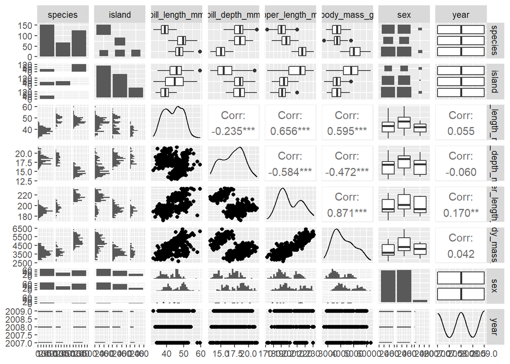

```r
ggpairs(penguins)
```

That’s kind of overkill. Let’s simplify the variables that we include in our ggpairs plot:

- species
- bill_length_mm through body_mass_g

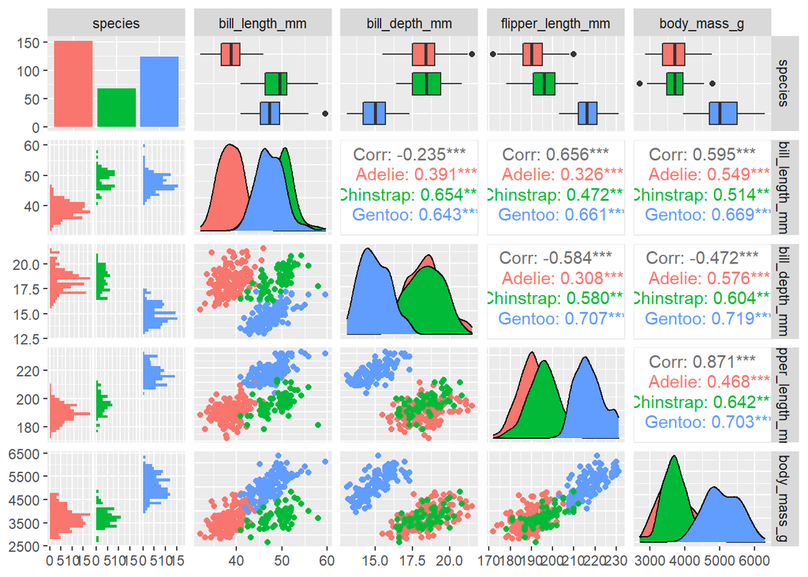

```r
penguins %>%
  select(species, bill_length_mm:body_mass_g) %>%
  ggpairs(aes(color = species))
```

## Multiple Linear Regression

We going to try to understand a bit better the relationships between multiple predictor variables and an outcome variable which is penguin body mass.

The different predictor variables we’re going to try are:

- species
- flipper length
- sex
- bill depth

### Model 1

Model body mass based only on flipper length and bill depth (bad idea… there are important variables missing)

```r
model_1 <- lm(body_mass_g ~ flipper_length_mm + bill_depth_mm, data = penguins)

# call model_1 to return only coefficients
model_1
```

```
##
## Call:
## lm(formula = body_mass_g ~ flipper_length_mm + bill_depth_mm,
##     data = penguins)
##
## Coefficients:
##       (Intercept)  flipper_length_mm      bill_depth_mm
##          -6541.91              51.54              22.63
```

```r
# more information on coefficients and stats
summary(model_1)
```

```
##
## Call:
## lm(formula = body_mass_g ~ flipper_length_mm + bill_depth_mm,
##     data = penguins)
##
## Residuals:
##      Min       1Q   Median       3Q      Max
## -1029.78  -271.45   -23.58   245.15  1275.97
##
## Coefficients:
##                    Estimate Std. Error t value Pr(>|t|)
## (Intercept)       -6541.907    540.751 -12.098   <2e-16 ***
## flipper_length_mm    51.541      1.865  27.635   <2e-16 ***
## bill_depth_mm        22.634     13.280   1.704   0.0892 .
## ---
## Signif. codes:  0 '***' 0.001 '**' 0.01 '*' 0.05 '.' 0.1 ' ' 1
##
## Residual standard error: 393.2 on 339 degrees of freedom
##   (2 observations deleted due to missingness)
## Multiple R-squared:  0.761,  Adjusted R-squared:  0.7596
## F-statistic: 539.8 on 2 and 339 DF,  p-value: < 2.2e-16
```

Flipper length coefficient: If everything else is held constant, we expect that for each 1 mm increase in flipper length, penguin body mass is expected to increase by 51.54 g, on average.

R2 = 0.76: 76% of the variance in penguin body mass is explained by this model, which contains flipper length and bill depth.

Actually – we think that a model for penguin body mass should contain variables species, flipper length, and sex.

```r
model_2 = lm(body_mass_g ~ species + flipper_length_mm + sex, data = penguins)

summary(model_2)
```

```
##
## Call:
## lm(formula = body_mass_g ~ species + flipper_length_mm + sex,
##     data = penguins)
##
## Residuals:
##    Min     1Q Median     3Q    Max
## -721.8 -195.7   -5.9  198.6  873.7
##
## Coefficients:
##                   Estimate Std. Error t value Pr(>|t|)
## (Intercept)       -365.817    532.050  -0.688   0.4922
## speciesChinstrap   -87.634     46.347  -1.891   0.0595 .
## speciesGentoo      836.260     85.185   9.817  < 2e-16 ***
## flipper_length_mm   20.025      2.846   7.037 1.15e-11 ***
## sexmale            530.381     37.810  14.027  < 2e-16 ***
## ---
## Signif. codes:  0 '***' 0.001 '**' 0.01 '*' 0.05 '.' 0.1 ' ' 1
##
## Residual standard error: 295.6 on 328 degrees of freedom
##   (11 observations deleted due to missingness)
## Multiple R-squared:  0.8669, Adjusted R-squared:  0.8653
## F-statistic:   534 on 4 and 328 DF,  p-value: < 2.2e-16
```

References:

- Species = Adelie
- Sex = Female

Try interpreting coefficients for flipper length, Gentoo, and male

- Flipper length: For every 1 mm increase in flipper length, we would expect, on average, a 20 g increase in body mass if all other variables are held constant.
- Gentoo: If all other variables are held constant, if a penguin is Gentoo, we would expect it to be 836 g larger in body mass, on average, than an Adelie that is otherwise similar.
- Male: On average, we expect a male penguin to be 530 g larger in body mass than a female, if all other variables are held constant.

## Visualize this model

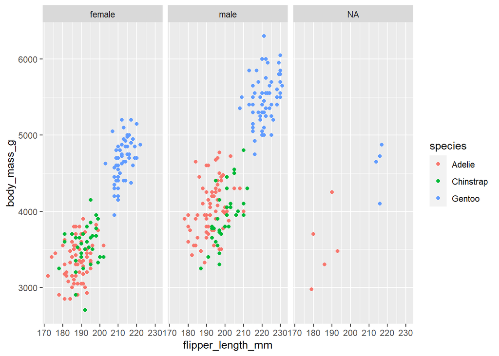

```r
ggplot(data = penguins,
       aes(x = flipper_length_mm, y = body_mass_g)) +
  geom_point(aes(color = species)) +
  facet_wrap(~ sex)
```

## A couple ways to get and report MLR model outcomes

Use broom::tidy() to get model coefficient info into tidy format

```r
penguin_model2_coef <- tidy(model_2)
```

Try to write inline code `r` that returns the coefficient for Gentoo:

836.2600081

## Look at model diagnostics

Use the plot() function

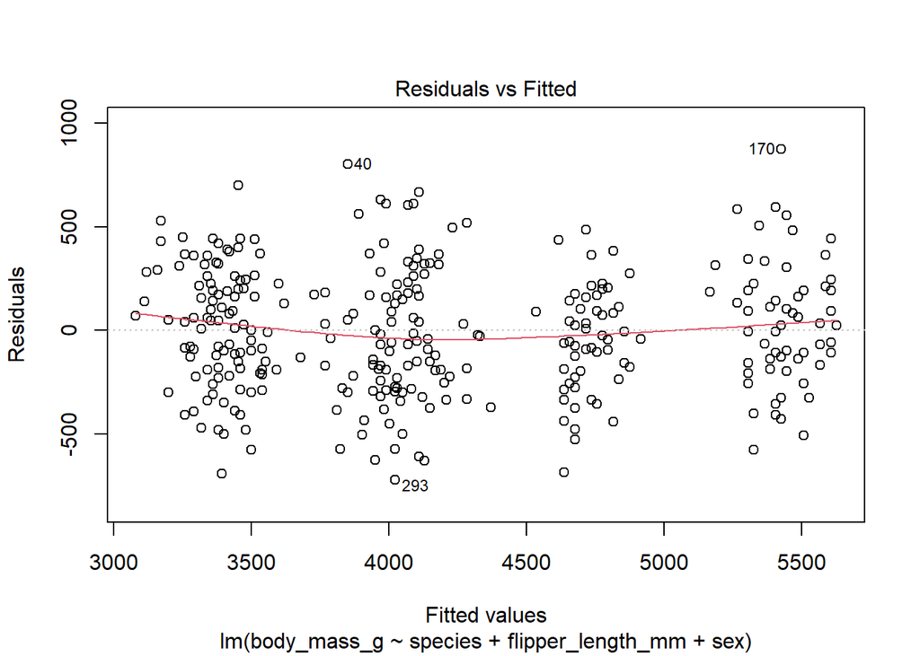

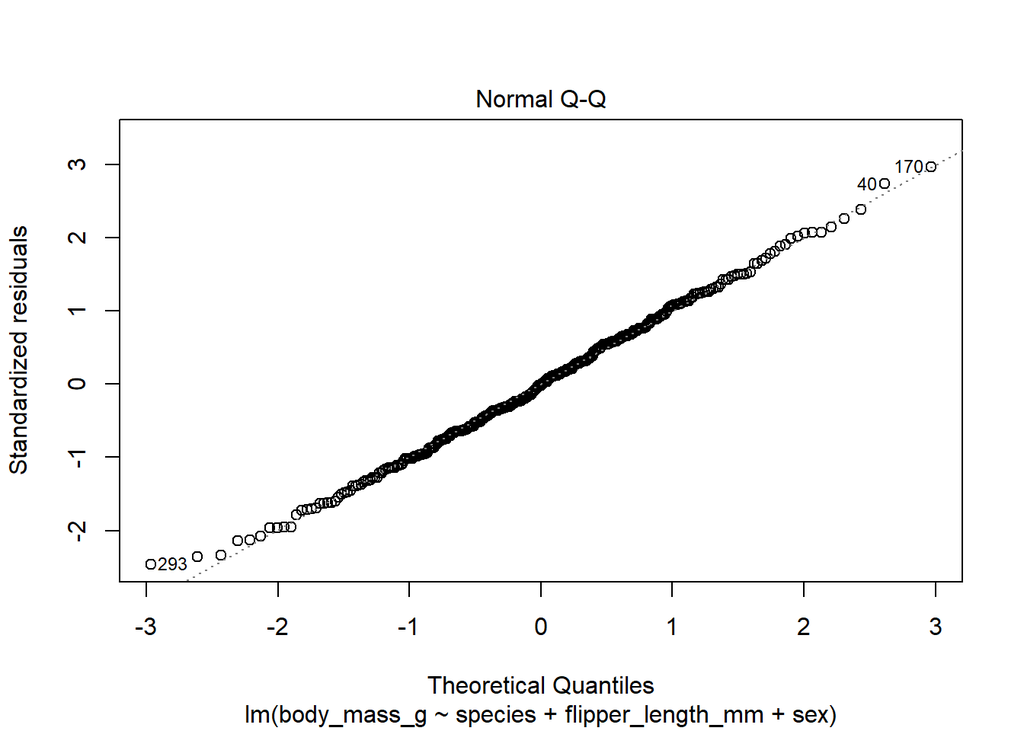

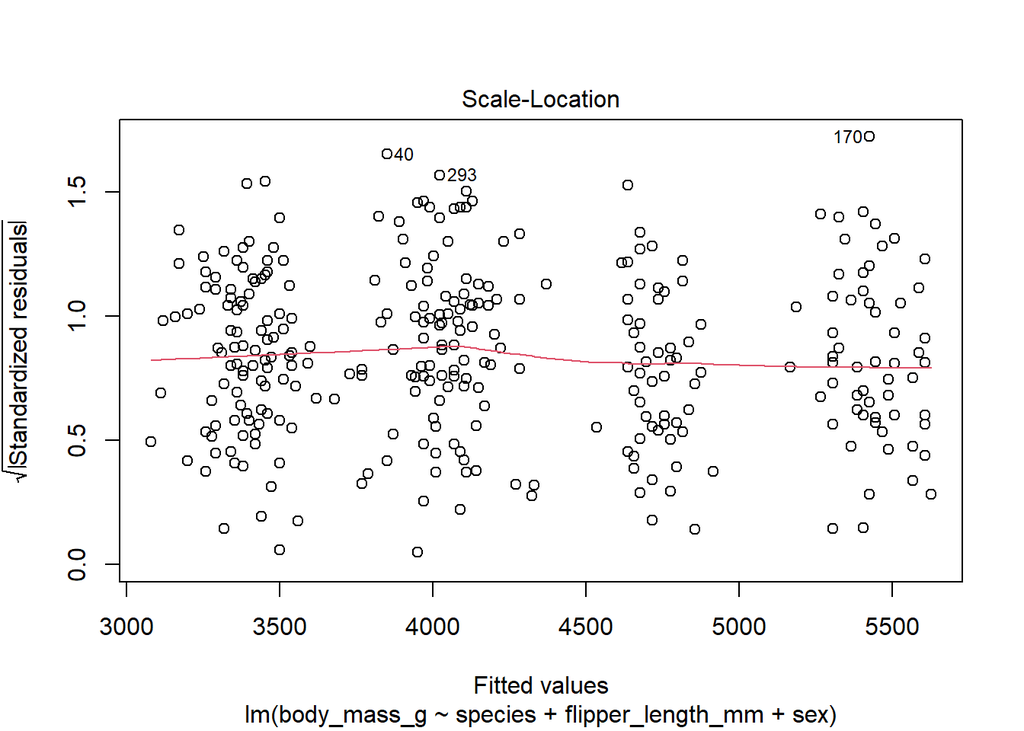

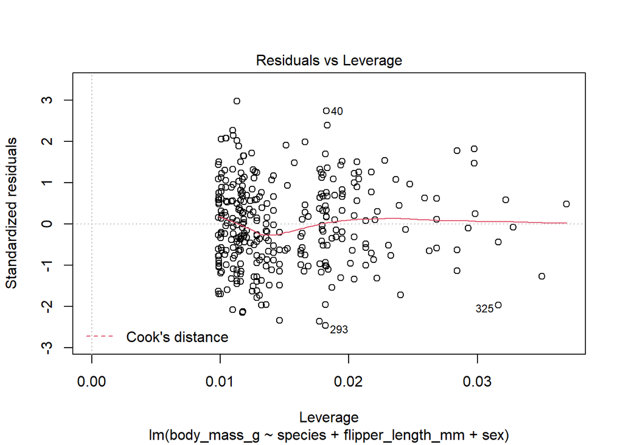

```r
plot(model_2)
```

```r
summary(model_2)
```

```
##
## Call:
## lm(formula = body_mass_g ~ species + flipper_length_mm + sex,
##     data = penguins)
##
## Residuals:
##    Min     1Q Median     3Q    Max
## -721.8 -195.7   -5.9  198.6  873.7
##
## Coefficients:
##                   Estimate Std. Error t value Pr(>|t|)
## (Intercept)       -365.817    532.050  -0.688   0.4922
## speciesChinstrap   -87.634     46.347  -1.891   0.0595 .
## speciesGentoo      836.260     85.185   9.817  < 2e-16 ***
## flipper_length_mm   20.025      2.846   7.037 1.15e-11 ***
## sexmale            530.381     37.810  14.027  < 2e-16 ***
## ---
## Signif. codes:  0 '***' 0.001 '**' 0.01 '*' 0.05 '.' 0.1 ' ' 1
##
## Residual standard error: 295.6 on 328 degrees of freedom
##   (11 observations deleted due to missingness)
## Multiple R-squared:  0.8669, Adjusted R-squared:  0.8653
## F-statistic:   534 on 4 and 328 DF,  p-value: < 2.2e-16
```

R2 = 0.87: 87% of the variance in penguin body mass is explained by this model, which contains flipper length, species, and sex.

## Report the model outputs in a summary table

Use modelsummary()

```r
modelsummary(model_2)
```

|  | Model 1 |
| --- | --- |
| (Intercept) | -365.817 |
|  | (532.050) |
| speciesChinstrap | -87.634 |
|  | (46.347) |
| speciesGentoo | 836.260 |
|  | (85.185) |
| flipper_length_mm | 20.025 |
|  | (2.846) |
| sexmale | 530.381 |
|  | (37.810) |
| Num.Obs. | 333 |
| R2 | 0.867 |
| R2 Adj. | 0.865 |
| AIC | 4740.8 |
| BIC | 4763.6 |
| Log.Lik. | -2364.387 |
| F | 534.024 |

Use stargazer

```r
stargazer(model_2, type = "html")
```

|  | *Dependent variable:* |
| --- | --- |
|  | body_mass_g |
| speciesChinstrap | -87.634* |
|  | (46.347) |
| speciesGentoo | 836.260*** |
|  | (85.185) |
| flipper_length_mm | 20.025*** |
|  | (2.846) |
| sexmale | 530.381*** |
|  | (37.810) |
| Constant | -365.817 |
|  | (532.050) |
| Observations | 333 |
| R<sup>2</sup> | 0.867 |
| Adjusted R<sup>2</sup> | 0.865 |
| Residual Std. Error | 295.565 (df = 328) |
| F Statistic | 534.024*** (df = 4; 328) |
| *Note:* | p<0.1; p<0.05; p<0.01 |